# REPORT

## ML Assignment: Food Delivery Time Prediction

### 1. Methodology and some comments

1. **This submission closely follows the sklearn guideline**, by preparing the processing, fitting, transforming, and evaluation steps as sklearn-compliant pipes.
2. Structuring everything into an sklearn pipeline **streamlines plug-and-playing things**, which enables quick iteration over experiments and ideas.
3. **The notebook generates all results via one pipeline** that runs all the necessary steps in sequence. This produces clean and scalable reports.
4. **Everything in this submission is runnable via Docker**. This is to sidestep all virtual environment and reproducibility issues.
5. **My dev-flow** when preparing this submission was:
- Prepare **high and mid-level scaffolding as pseudo-code**, and use **Claude Fable 5 to produce the low-level code**.
- Then I did several **self-review rounds to make sure everything is logically sound**, and the **results are clean and easy to follow**.
4. I really enjoyed this assignment so **many thanks to who prepared it** !

## Key assumptions and high-level implementaion comments

- Missing values arrive as the literal string `"NaN"`, every string has trailing whitespace.
- Test rows share the train date range and every test courier appears in train → the test set is an i.i.d. sample, so **shuffled K-fold CV** is the right validation.
- The target stays on its original scale. A log1p transform was tried as an experiment and did not help (the target is only mildly skewed).
- Impossible values are treated as missing rather than kept or dropped: ratings above 5, and the `0` / `0.01` coordinate placeholders (about 8 % of rows). Negative coordinates are sign-flipped, since all cities are in India.
- Missingness is informative, not random (rows with a missing field average 23.8 minutes vs 26.6 without) → missing values are kept as flags and handled natively by the model instead of dropping rows.
- Model selection uses out-of-fold MAE only; the test set is never looked at. The winner is refit once on all training rows before predicting `test.csv`.
- Everything is seeded (seed 0) and runs on CPU inside Docker, so every number in this report is reproducible with `make train`.

## 1. What was built

**Structure.**

- One versioned experiment module (`delivery/exp/v001_hgb_vs_mlp_kfold5.py`)
- Each experiment makes a single call into a generic pipeline (`delivery/pipeline/regression.py::execute`) that runs the experiment phases: validation → preparation → pre-analysis → baselines → cross-validation → holdout diagnostics → experiments → refit + predict → dump → post-analysis.

**Model pipeline.** Everything the model needs lives inside one sklearn pipeline, so cross-validation cannot leak and `test.csv` goes through exactly the same steps as `train.csv`:

`DeliveryCleaner` → `DeliveryFeatureEngineer` → `ColumnTransformer` → model

1. **Cleaning.** The raw file is noisy: missing values are the text `"NaN"`, every string has trailing whitespace, ages and ratings are strings, and the target is written as `"(min) 24"`. The cleaner fixes all of this in one place. It also treats impossible values as missing: ratings above 5, and the `0` / `0.01` coordinate placeholders (about 8 % of rows). Negative coordinates are sign-flipped, since all the cities are in India.
2. **Features.** Engineered inside the pipeline from the cleaned columns:

| feature | built from | why |
| --- | --- | --- |
| distance (km) | restaurant and customer coordinates (haversine) | the main physical driver of delivery time |
| order time, pickup time | the two timestamps, as minutes of the day | time-of-day effects |
| preparation time | pickup − order (with midnight wrap) | how long the restaurant took |
| weekday, weekend, day, month | order date | calendar effects |
| missing-value flags | one per field that can be missing | missingness itself is informative |
| courier city | prefix of the courier ID (22 cities) | city-level differences |
| age, rating, vehicle condition, extra deliveries, restaurant lat/lon | raw columns, as-is after cleaning | courier and location proxies |

I deliberately did not use courier history or target encoding: it leaks inside cross-validation, and the test set is a random sample of the same period rather than the future.

3. **Encoding.** One encoder per model family, both sklearn `ColumnTransformer`s:

| model family | numeric features | categorical features | missing values |
| --- | --- | --- | --- |
| tree (gradient boosting, median) | as-is | integer codes, handled natively by the model | kept, handled natively |
| dense (Ridge, MLP) | median imputation + standardisation | one-hot (unknown level → all zeros) | imputed |

4. **Models.** Four candidates, same pipeline, same folds:

| candidate | model | loss | role |
| --- | --- | --- | --- |
| median | `DummyRegressor` | — | floor |
| ridge | `Ridge` | squared error | linear baseline |
| hgb | `HistGradientBoostingRegressor` | absolute error (= MAE, the metric) | main candidate, selected |
| mlp | `TorchMLPRegressor` (PyTorch, two hidden layers, early stopping) | Huber | neural candidate |

I wrote the MLP to the sklearn estimator contract and verified it with sklearn's own `check_estimator` suite, so it drops into `Pipeline`, `clone` and `cross_validate` like any other estimator.

**Evaluation pipeline.** Also sklearn-style, and bespoke to this task:

- scorers built with `make_scorer`: MAE as the primary metric, plus RMSE, median absolute error, R², and the share of deliveries predicted within ±5 minutes, which is the number I would show a business stakeholder;
- a `DeliverySlicer` that maps every row to the error slices used below (traffic, distance bucket, city, time of day, weather, multiple deliveries);
- a `DeliveryEvaluator` that runs `cross_validate`, stitches the out-of-fold predictions together and produces the leaderboard, the per-fold scores and the per-slice tables;
- display objects in the sklearn `from_estimator / from_predictions / plot(ax=)` style, so the same figures work on any fitted estimator.

## 2. Validation setup and results

**Why shuffled 5-fold cross-validation.** `test.csv` covers the same dates as `train.csv` (11 Feb to 6 Apr 2022) and every test courier appears in the training data. So the test set is a random sample of the same distribution, not a future period, and a shuffled K-fold mirrors that. I still ran a courier-grouped split as a robustness check (Section 3).

**Every number in this report is out-of-fold.** Each training row is predicted by a model that never saw it. The 80/20 holdout in the diagnostics section below tells the same story.

| model | MAE | RMSE | MedAE | R² | within ±5 min | bias | MAE fold std |
| --- | --- | --- | --- | --- | --- | --- | --- |
| **gradient boosting** (selected) | **3.153** | 4.047 | 2.634 | 0.814 | 81.1 % | −0.20 | 0.030 |
| MLP (PyTorch, Huber loss) | 3.410 | 4.350 | 2.846 | 0.785 | 76.9 % | −0.06 | 0.026 |
| Ridge | 4.857 | 6.082 | 4.156 | 0.579 | 58.5 % | 0.00 | 0.024 |
| median baseline | 7.564 | 9.384 | 7.000 | −0.001 | 41.8 % | −0.32 | 0.038 |

**Takeaways:**

1. **Gradient boosting wins** clearly: an MAE of about 3.2 minutes, with 81 % of deliveries predicted within 5 minutes of the truth, against a median-baseline MAE of 7.6.
2. **The ranking is stable**. Per-fold MAE for boosting is 3.12 / 3.12 / 3.18 / 3.19 / 3.16, and the MLP is about 0.25 minutes worse on every single fold.
3. The courier-grouped split gives 3.155 against 3.153, so **the model is not memorising couriers**.
4. **The selected model is refit** on all 41,093 rows before predicting `test.csv`. The predictions average 25.9 minutes against a training mean of 26.3, which is what I would expect from a random split.

## 3. Experiments: what I tried and what helped

I ran a small experiment ladder of 12 variants on the same folds (the full table is in the *[Analysis] Experiments* section below and in `outputs/experiments.json`). What I learned:

1. **The model family matters far more than anything else.** Boosting 3.15, MLP 3.41, linear 4.86, median 7.56. Delivery time is driven by interactions between traffic, distance and time of day, and trees pick those sufficiently.
2. **Boosting barely cares about tuning.** Out-of-the-box settings (squared loss, 100 iterations) land within 0.003 MAE of the tuned model. I kept the tuned absolute-error version because it is marginally best on the metric, but the honest reading is that the 3.15 floor comes from the features, not from the hyper-parameters.
3. **A log-transformed target does not help** (3.157 against 3.153). The target is only mildly skewed and the model already optimises an absolute-error loss on the raw scale, so the submission uses the raw target.
4. **Distance is the most valuable engineered feature.** Removing it costs 0.23 MAE. Removing the order and pickup time features changes nothing: the gap between them is a near-constant 5 to 15 minutes, and time of day is already captured by traffic density.

## 4. Error analysis

The figures and full tables are in the *[Analysis] Error analysis* section below.

The pattern is simple: the residual error sits on (a) rows where the informative fields are missing, and (b) the slow deliveries (jams, evenings, long distances), which are systematically under-predicted by roughly half a minute because within those cells the true distribution has a long right tail that the available features cannot resolve.

## 5. Limitations and what I would do next

1. **The remaining error is mostly irreducible with these features.** Within a given traffic / distance / time cell the spread of delivery times is wide and nothing in the data explains it. The next real signal would be history: previous durations of the same courier or restaurant, or a live queue length.
2. **Hyper-parameters were hand-tuned on a small ladder, not searched.** A randomised search over the boosting and MLP settings is the obvious next step; the evaluation pipeline already exposes sklearn scorers for it.
3. **The MLP trails boosting by 0.25 minutes.** Untried options: longer training schedules, and averaging a few seeds, which is cheap and usually worth a small gain.

## 6. Tooling disclosure

- I used Claude Code (Claude Fable 5.1) as a pair-programming assistant.
- As described in the methodology section: I prepared the high- and mid-level design, and Fable produced most of the low-level code and the tests.
- Every number in this report was produced by running the code in this repository (`make test`, `make train`, `make experiments`, and the pipeline cell below); nothing was estimated by hand.

**Libraries used**: scikit-learn 1.9, PyTorch 2.14 (CPU), pandas 3.0, numpy 2.5, matplotlib 3.11.

Pre-analysis: v001_hgb_vs_mlp_kfold5

Everything in this section is computed on the training rows only, before any model is fitted; it informs feature choices, it is not used for model selection.

[Analysis] Missing values

missing-value literals per raw column

| column | share | n | mean_target_when_missing | mean_target_when_present |
| --- | --- | --- | --- | --- |
| Delivery_person_Ratings | 4.2% | 1,718 | 26.385 | 26.318 |
| Delivery_person_Age | 4.1% | 1,666 | 26.421 | 26.317 |
| Time_Orderd | 3.8% | 1,559 | 26.239 | 26.324 |
| City | 2.6% | 1,080 | 22.095 | 26.435 |
| multiple_deliveries | 2.2% | 901 | 22.879 | 26.398 |
| Weatherconditions | 1.3% | 542 | 26.448 | 26.320 |
| Road_traffic_density | 1.3% | 529 | 26.482 | 26.319 |
| Festival | 0.5% | 202 | 11.168 | 26.396 |

9.3% of rows have at least one missing field; 4.4% have two or more (max 7). Mean target with any missing field: 23.81 vs 26.58 without.

co-missingness: P(column missing | row missing)

| column P(col missing \| row missing) | Delivery_person_Ratings | Delivery_person_Age | Time_Orderd | City | multiple_deliveries | Weatherconditions | Road_traffic_density | Festival |
| --- | --- | --- | --- | --- | --- | --- | --- | --- |
| Delivery_person_Ratings | 1.00 | 0.97 | 0.86 | 0.03 | 0.03 | 0.27 | 0.26 | 0.01 |
| Delivery_person_Age | 1.00 | 1.00 | 0.89 | 0.04 | 0.03 | 0.28 | 0.27 | 0.01 |
| Time_Orderd | 0.95 | 0.95 | 1.00 | 0.03 | 0.03 | 0.35 | 0.34 | 0.01 |
| City | 0.06 | 0.05 | 0.05 | 1.00 | 0.03 | 0.02 | 0.02 | 0.02 |
| multiple_deliveries | 0.06 | 0.06 | 0.05 | 0.03 | 1.00 | 0.01 | 0.01 | 0.01 |
| Weatherconditions | 0.85 | 0.85 | 1.00 | 0.04 | 0.01 | 1.00 | 0.98 | 0.01 |
| Road_traffic_density | 0.84 | 0.84 | 1.00 | 0.04 | 0.01 | 1.00 | 1.00 | 0.01 |
| Festival | 0.05 | 0.05 | 0.04 | 0.09 | 0.05 | 0.01 | 0.01 | 1.00 |

[Analysis] Target

target statistics (minutes)

|  | count | mean | std | min | 25% | 50% | 75% | max | skew |
| --- | --- | --- | --- | --- | --- | --- | --- | --- | --- |
| target | 41093.0 | 26.32 | 9.38 | 10.0 | 19.0 | 26.0 | 32.0 | 54.0 | 0.48 |

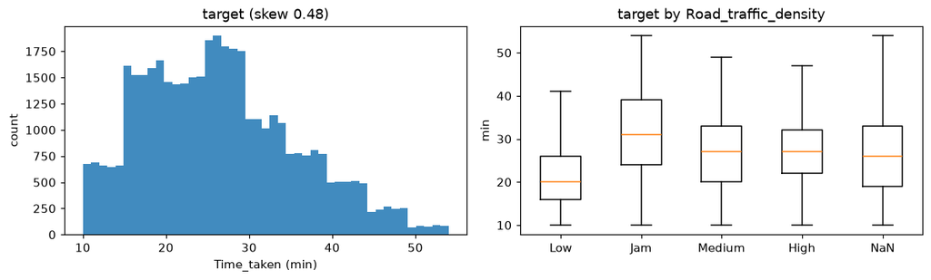

[Analysis] Engineered features

engineered numeric features

| feature | mean | std | min | 50% | max | missing_share |
| --- | --- | --- | --- | --- | --- | --- |
| Delivery_person_Age | 29.58 | 5.82 | 15.00 | 30.00 | 50.00 | 4.1% |
| Delivery_person_Ratings | 4.63 | 0.33 | 1.00 | 4.70 | 5.00 | 4.3% |
| Vehicle_condition | 1.02 | 0.84 | 0.00 | 1.00 | 3.00 | 0.0% |
| multiple_deliveries | 0.75 | 0.57 | 0.00 | 1.00 | 3.00 | 2.2% |
| Restaurant_latitude | 18.92 | 5.47 | 9.96 | 19.07 | 30.91 | 8.0% |
| Restaurant_longitude | 76.93 | 3.51 | 72.77 | 76.62 | 88.43 | 8.0% |
| distance_km | 9.72 | 5.60 | 1.47 | 9.19 | 20.97 | 8.0% |
| order_hour | 17.43 | 4.82 | 0.00 | 19.00 | 23.00 | 3.8% |
| order_minute_of_day | 1075.10 | 290.62 | 0.00 | 1155.00 | 1435.00 | 3.8% |
| picked_minute_of_day | 1056.94 | 322.66 | 0.00 | 1150.00 | 1435.00 | 0.0% |
| prep_time_min | 9.99 | 4.09 | 5.00 | 10.00 | 15.00 | 3.8% |
| weekday | 2.99 | 1.97 | 0.00 | 3.00 | 6.00 | 0.0% |
| is_weekend | 0.27 | 0.45 | 0.00 | 0.00 | 1.00 | 0.0% |
| day_of_month | 13.82 | 8.71 | 1.00 | 13.00 | 31.00 | 0.0% |
| month | 2.98 | 0.55 | 2.00 | 3.00 | 4.00 | 0.0% |
| age_missing | 0.04 | 0.20 | 0.00 | 0.00 | 1.00 | 0.0% |
| ratings_missing | 0.04 | 0.20 | 0.00 | 0.00 | 1.00 | 0.0% |
| order_time_missing | 0.04 | 0.19 | 0.00 | 0.00 | 1.00 | 0.0% |
| coords_missing | 0.08 | 0.27 | 0.00 | 0.00 | 1.00 | 0.0% |

26 engineered features: 19 numeric, 1 ordinal, 6 nominal — from 41,093 rows.

[Analysis] Correlations

spearman correlation with the target

| feature | spearman with target |
| --- | --- |
| multiple_deliveries | 0.339 |
| distance_km | 0.319 |
| Delivery_person_Age | 0.311 |
| Delivery_person_Ratings | -0.297 |
| Vehicle_condition | -0.223 |
| picked_minute_of_day | 0.129 |
| order_hour | 0.102 |
| order_minute_of_day | 0.101 |
| day_of_month | 0.024 |
| month | -0.013 |
| Restaurant_latitude | 0.013 |
| coords_missing | -0.008 |
| Restaurant_longitude | 0.007 |
| weekday | 0.006 |
| prep_time_min | -0.006 |
| order_time_missing | -0.003 |
| ratings_missing | -0.002 |
| is_weekend | -0.002 |
| age_missing | -0.000 |

feature pairs with |spearman| ≥ 0.9 (redundant for linear models)

| pair | spearman |
| --- | --- |
| order_hour ~ order_minute_of_day | 0.996 |
| age_missing ~ ratings_missing | 0.970 |
| ratings_missing ~ order_time_missing | 0.915 |
| age_missing ~ order_time_missing | 0.912 |

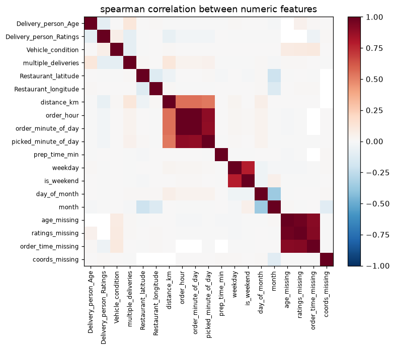

[Analysis] Categorical effects

mean target per level (top levels by mean; 'unknown' = missing)

| feature | level | n | share | mean_target | std_target | lift_vs_mean |
| --- | --- | --- | --- | --- | --- | --- |
| Road_traffic_density | Jam | 12,747 | 31.0% | 31.215 | 9.923 | 4.893 |
|  | High | 3,986 | 9.7% | 27.271 | 8.380 | 0.950 |
|  | Medium | 9,845 | 24.0% | 26.713 | 8.552 | 0.392 |
|  | unknown | 529 | 1.3% | 26.482 | 9.363 | 0.161 |
|  | Low | 13,986 | 34.0% | 21.309 | 6.826 | -5.013 |
| multiple_deliveries | 3 | 328 | 0.8% | 47.899 | 3.470 | 21.578 |
|  | 2 | 1,788 | 4.4% | 40.437 | 4.918 | 14.116 |
|  | 1 | 25,396 | 61.8% | 26.880 | 8.524 | 0.558 |
|  | 0 | 12,680 | 30.9% | 22.899 | 8.777 | -3.422 |
|  | unknown | 901 | 2.2% | 22.879 | 8.770 | -3.442 |
| Festival | Yes | 818 | 2.0% | 45.504 | 4.013 | 19.182 |
|  | No | 40,073 | 97.5% | 26.006 | 9.005 | -0.315 |
|  | unknown | 202 | 0.5% | 11.168 | 1.238 | -15.153 |
| Weatherconditions | Fog | 6,936 | 16.9% | 28.935 | 10.142 | 2.613 |
|  | Cloudy | 6,790 | 16.5% | 28.933 | 10.058 | 2.611 |
|  | unknown | 542 | 1.3% | 26.448 | 9.353 | 0.127 |
|  | Windy | 6,690 | 16.3% | 26.132 | 8.613 | -0.189 |
|  | Stormy | 6,830 | 16.6% | 25.881 | 8.453 | -0.440 |
|  | Sandstorms | 6,770 | 16.5% | 25.860 | 8.600 | -0.461 |
|  | Sunny | 6,535 | 15.9% | 21.955 | 8.399 | -4.367 |
| City | Semi-Urban | 146 | 0.4% | 49.767 | 2.737 | 23.446 |
|  | Metropolitian | 30,760 | 74.9% | 27.341 | 9.182 | 1.020 |
|  | Urban | 9,107 | 22.2% | 23.003 | 8.868 | -3.318 |
|  | unknown | 1,080 | 2.6% | 22.095 | 8.180 | -4.226 |
| Type_of_vehicle | motorcycle | 23,801 | 57.9% | 27.643 | 9.637 | 1.321 |
|  | bicycle | 63 | 0.2% | 25.746 | 8.959 | -0.575 |
|  | electric_scooter | 3,438 | 8.4% | 24.512 | 8.618 | -1.809 |
|  | scooter | 13,791 | 33.6% | 24.494 | 8.705 | -1.827 |
| Type_of_order | Meal | 10,352 | 25.2% | 26.440 | 9.422 | 0.119 |
|  | Buffet | 10,166 | 24.7% | 26.337 | 9.422 | 0.016 |
|  | Snack | 10,358 | 25.2% | 26.313 | 9.398 | -0.009 |
|  | Drinks | 10,217 | 24.9% | 26.194 | 9.272 | -0.128 |
| driver_city | ALH | 658 | 1.6% | 27.128 | 9.582 | 0.806 |
|  | BHP | 625 | 1.5% | 27.002 | 9.418 | 0.680 |
|  | DEH | 661 | 1.6% | 26.823 | 9.814 | 0.502 |
|  | AGR | 698 | 1.7% | 26.772 | 9.595 | 0.451 |
|  | JAP | 3,080 | 7.5% | 26.744 | 9.503 | 0.423 |
|  | AURG | 635 | 1.5% | 26.726 | 9.216 | 0.405 |
|  | KOC | 622 | 1.5% | 26.489 | 9.568 | 0.168 |
|  | HYD | 2,862 | 7.0% | 26.471 | 9.466 | 0.150 |
|  | KNP | 666 | 1.6% | 26.374 | 9.319 | 0.053 |
|  | LUDH | 690 | 1.7% | 26.372 | 9.450 | 0.051 |
|  | COIMB | 2,872 | 7.0% | 26.364 | 9.413 | 0.043 |
|  | CHEN | 2,834 | 6.9% | 26.354 | 9.383 | 0.033 |

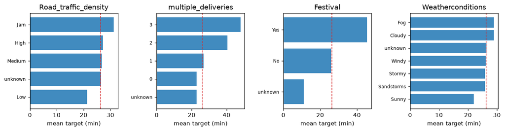

```
[v001_hgb_vs_mlp_kfold5] Step4: 4 candidates: ['median', 'ridge', 'hgb', 'mlp']
```

```
[v001_hgb_vs_mlp_kfold5] Step5: cross-validation with KFold(n_splits=5, random_state=0, shuffle=True)
```

```
[evaluate] median ...
```

```
[evaluate] median: mae=7.564  rmse=9.384  within_5min=0.418  fit=1.2s
```

```
[evaluate] ridge ...
```

```
[evaluate] ridge: mae=4.857  rmse=6.082  within_5min=0.585  fit=1.5s
```

```
[evaluate] hgb ...
```

```
[evaluate] hgb: mae=3.153  rmse=4.047  within_5min=0.811  fit=8.2s
```

```
[evaluate] mlp ...
```

```
[evaluate] mlp: mae=3.410  rmse=4.350  within_5min=0.769  fit=40.7s
```

```
[v001_hgb_vs_mlp_kfold5] Step5: winner = hgb (MAE 3.153)
```

```
[v001_hgb_vs_mlp_kfold5] Step6: holdout fit of hgb
```

```
[v001_hgb_vs_mlp_kfold5] Step6: holdout fit of mlp
```

```
[v001_hgb_vs_mlp_kfold5] Step7: experiment 'hgb (log1p target)'
```

```
[v001_hgb_vs_mlp_kfold5] Step7: hgb (log1p target): mae=3.157
```

```
[v001_hgb_vs_mlp_kfold5] Step7: experiment 'hgb (GroupKFold by courier)'
```

```
[v001_hgb_vs_mlp_kfold5] Step7: hgb (GroupKFold by courier): mae=3.155
```

```
[v001_hgb_vs_mlp_kfold5] Step8: refit hgb on all 41093 rows
```

```
[v001_hgb_vs_mlp_kfold5] Step8: wrote submission (4500 rows, mean 25.88)
```

```
[v001_hgb_vs_mlp_kfold5] Step9: artefacts under /app/outputs (81.8s)
```

Post-analysis: v001_hgb_vs_mlp_kfold5

[Analysis] Data

train rows **41,093** · test rows **4,500** · target mean **26.32** min, std 9.38, range [10, 54] · seed 0 · cv KFold(n_splits=5, random_state=0, shuffle=True) · candidates median, ridge, hgb, mlp

[Analysis] Cross-validated leaderboard

KFold(n_splits=5, random_state=0, shuffle=True) — out-of-fold

| model | mae | rmse | medae | mape | r2 | within_5min | bias | mae_fold_std | fit_time_s |
| --- | --- | --- | --- | --- | --- | --- | --- | --- | --- |
| hgb | 3.153 | 4.047 | 2.634 | 0.136 | 0.814 | 81.1% | -0.197 | 0.030 | 8.211 |
| mlp | 3.410 | 4.350 | 2.846 | 0.148 | 0.785 | 76.9% | -0.061 | 0.026 | 40.712 |
| ridge | 4.857 | 6.082 | 4.156 | 0.214 | 0.579 | 58.5% | 0.001 | 0.024 | 1.451 |
| median | 7.564 | 9.384 | 7.000 | 0.339 | -0.001 | 41.8% | -0.321 | 0.038 | 1.220 |

Selected model: **hgb** — CV MAE **3.153 min**, 81.1% of deliveries predicted within ±5 min (RMSE 4.047, bias -0.20).

hgb: per-fold scores

| fold | mae | rmse | medae | mape | r2 | within_5min |
| --- | --- | --- | --- | --- | --- | --- |
| 0 | 3.118 | 3.965 | 2.612 | 0.133 | 0.821 | 81.4% |
| 1 | 3.119 | 4.005 | 2.600 | 0.136 | 0.815 | 81.8% |
| 2 | 3.178 | 4.111 | 2.636 | 0.136 | 0.808 | 80.9% |
| 3 | 3.191 | 4.088 | 2.652 | 0.137 | 0.813 | 80.6% |
| 4 | 3.157 | 4.063 | 2.669 | 0.138 | 0.811 | 81.0% |

[Analysis] Training diagnostics

80/20 (seed 0) holdout

| model | mae | rmse | medae | mape | r2 | within_5min | bias | fit_time_s |
| --- | --- | --- | --- | --- | --- | --- | --- | --- |
| hgb | 3.113 | 3.953 | 2.609 | 0.133 | 0.822 | 81.3% | -0.229 | 1.047 |
| mlp | 3.346 | 4.245 | 2.781 | 0.145 | 0.795 | 77.9% | -0.063 | 7.331 |

**mlp**: 43 / 80 epochs (early stopping, patience 10), loss `huber`, best internal-val MAE 3.397, holdout MAE 3.346.

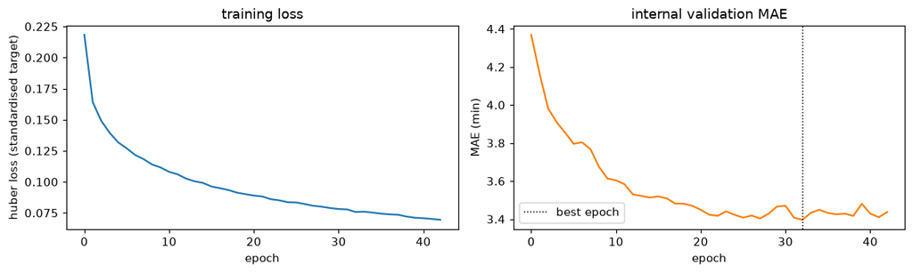

[Analysis] Experiments

winner vs. its variants (same folds)

| model | mae | rmse | within_5min | bias | mae_fold_std |
| --- | --- | --- | --- | --- | --- |
| hgb | 3.153 | 4.047 | 81.1% | -0.197 | 0.030 |
| hgb (GroupKFold by courier) | 3.155 | 4.046 | 81.2% | -0.179 | 0.026 |
| hgb (log1p target) | 3.157 | 4.056 | 81.0% | -0.230 | 0.028 |

experiment ladder (5-fold, `python -m delivery.experiments`)

| variant | mae | rmse | within_5min | bias | mae_fold_std | fit_time_s |
| --- | --- | --- | --- | --- | --- | --- |
| hgb: tuned, without order/pickup time | 3.153 | 4.051 | 81.4% | -0.204 | 0.029 | 5.217 |
| hgb: tuned (lr .05, 600 iters, 63 leaves, min_leaf 40) | 3.153 | 4.047 | 81.1% | -0.197 | 0.030 | 6.643 |
| hgb: default (squared loss, 100 iters) | 3.156 | 3.976 | 80.6% | -0.009 | 0.031 | 2.726 |
| hgb: tuned, log1p target | 3.157 | 4.056 | 81.0% | -0.230 | 0.028 | 6.020 |
| blend: 0.7 hgb + 0.3 mlp | 3.169 | 4.060 | 80.6% | -0.189 | 0.032 | 71.539 |
| hgb: absolute_error loss | 3.181 | 4.076 | 80.7% | -0.226 | 0.028 | 3.197 |
| hgb: tuned, without distance | 3.383 | 4.360 | 77.7% | -0.206 | 0.034 | 9.543 |
| mlp: same, Huber loss | 3.410 | 4.350 | 76.9% | -0.061 | 0.026 | 40.553 |
| mlp: same, MSE loss | 3.428 | 4.377 | 76.5% | 0.057 | 0.026 | 32.826 |
| mlp: (512,256,128) dropout .2 | 3.442 | 4.453 | 76.7% | -0.168 | 0.038 | 116.920 |
| mlp: (256,128) L1, early stop | 3.456 | 4.441 | 76.0% | -0.171 | 0.036 | 49.659 |
| mlp: (64,) no dropout | 3.717 | 4.758 | 72.7% | -0.174 | 0.046 | 31.205 |

[Analysis] Error analysis

`bias` = mean(predicted − actual): negative means under-prediction. All numbers are out-of-fold.

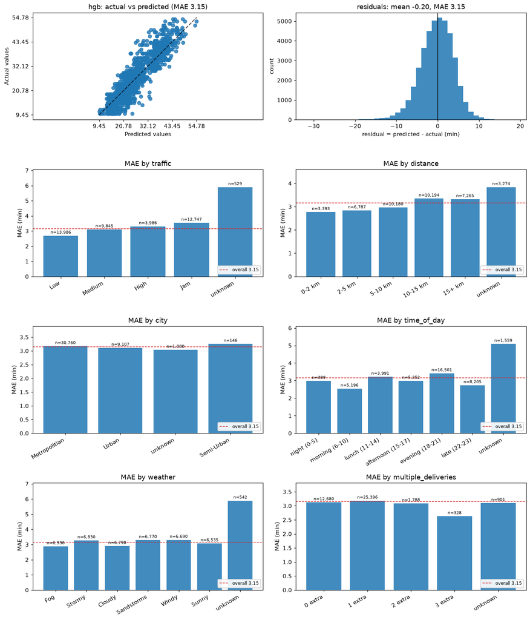

hgb by traffic

| slice | n | share | mae | rmse | bias | within_5min | mean_true |
| --- | --- | --- | --- | --- | --- | --- | --- |
| Low | 13,986 | 34.0% | 2.689 | 3.349 | 0.088 | 87.8% | 21.309 |
| Medium | 9,845 | 24.0% | 3.104 | 3.999 | -0.202 | 81.6% | 26.713 |
| High | 3,986 | 9.7% | 3.307 | 4.369 | -0.387 | 79.5% | 27.271 |
| Jam | 12,747 | 31.0% | 3.538 | 4.474 | -0.449 | 75.4% | 31.215 |
| unknown | 529 | 1.3% | 5.893 | 7.204 | -0.098 | 48.0% | 26.482 |

hgb by distance

| slice | n | share | mae | rmse | bias | within_5min | mean_true |
| --- | --- | --- | --- | --- | --- | --- | --- |
| 0-2 km | 3,393 | 8.3% | 2.766 | 3.500 | -0.055 | 86.8% | 21.469 |
| 2-5 km | 6,787 | 16.5% | 2.834 | 3.610 | -0.032 | 85.4% | 22.649 |
| 5-10 km | 10,180 | 24.8% | 2.962 | 3.904 | -0.044 | 83.6% | 24.397 |
| 10-15 km | 10,194 | 24.8% | 3.345 | 4.167 | -0.340 | 78.3% | 29.822 |
| 15+ km | 7,265 | 17.7% | 3.321 | 4.144 | -0.268 | 78.5% | 29.893 |
| unknown | 3,274 | 8.0% | 3.836 | 5.125 | -0.553 | 73.5% | 26.122 |

hgb by city

| slice | n | share | mae | rmse | bias | within_5min | mean_true |
| --- | --- | --- | --- | --- | --- | --- | --- |
| Metropolitian | 30,760 | 74.9% | 3.169 | 4.075 | -0.217 | 81.0% | 27.341 |
| Urban | 9,107 | 22.2% | 3.109 | 3.976 | -0.146 | 81.3% | 23.003 |
| unknown | 1,080 | 2.6% | 3.037 | 3.825 | 0.087 | 82.9% | 22.095 |
| Semi-Urban | 146 | 0.4% | 3.251 | 4.107 | -1.101 | 83.6% | 49.767 |

hgb by time_of_day

| slice | n | share | mae | rmse | bias | within_5min | mean_true |
| --- | --- | --- | --- | --- | --- | --- | --- |
| night (0-5) | 389 | 0.9% | 2.979 | 3.925 | -0.368 | 84.6% | 22.159 |
| morning (6-10) | 5,196 | 12.6% | 2.539 | 3.095 | 0.137 | 90.0% | 19.579 |
| lunch (11-14) | 3,991 | 9.7% | 3.217 | 4.220 | -0.347 | 80.5% | 26.916 |
| afternoon (15-17) | 5,252 | 12.8% | 2.984 | 3.834 | -0.161 | 83.2% | 26.246 |
| evening (18-21) | 16,501 | 40.2% | 3.413 | 4.320 | -0.385 | 77.1% | 30.148 |
| late (22-23) | 8,205 | 20.0% | 2.735 | 3.406 | 0.029 | 87.0% | 22.867 |
| unknown | 1,559 | 3.8% | 5.090 | 6.495 | -0.192 | 57.6% | 26.239 |

[Analysis] Submission

**hgb** refit on all 41,093 rows → 4,500 test predictions: mean 25.88 min (train mean 26.32), range [9.2, 54.8].

submission head

|  | ID | Time_taken (min) |
| --- | --- | --- |
| 0 | 0xc125 | 23.889 |
| 1 | 0xf18 | 24.706 |
| 2 | 0x4b92 | 33.944 |
| 3 | 0x31bb | 28.097 |
| 4 | 0x6756 | 18.388 |

**artefacts**

- `output_dir`: `/app/outputs`

- `model`: `/app/outputs/model.joblib`

- `best_model`: `/app/outputs/best_model.json`

- `submission`: `/app/outputs/submission.csv`

- `metrics`: `/app/outputs/metrics.json`

- `figures`: `/app/outputs/figures`

- `run_meta`: `/app/outputs/run_meta.json`